# Informe semanal, covid

Servicio de Medicina Preventiva, Hospital de Cruces

07 noviembre, 2022

# 1 Datos semanales

|  | 29ago./ 04sep. | 05sep./ 11sep. | 12sep./ 18sep. | 19sep./ 25sep. | 26sep./ 02oct. | 03oct./ 09oct. | 10oct./ 16oct. | 17oct./ 23oct. | 24oct./ 30oct. | 31oct./ 06nov. |
| --- | --- | --- | --- | --- | --- | --- | --- | --- | --- | --- |
| Hospital U. de Cruces |  |  |  |  |  |  |  |  |  |  |
| Casos COVID totales | 19 | 8 | 12 | 15 | 25 | 29 | 21 | 26 | 30 | 11 |
| Indicadores COVID |  |  |  |  |  |  |  |  |  |  |
| inesp_durante_ingreso | 1 | 0 | 0 | 2 | 5 | 7 | 2 | 3 | 0 | 0 |
| inesp_urgencias | 9 | 5 | 9 | 8 | 13 | 10 | 11 | 13 | 13 | 3 |
| Positividad en nuevos ingresos |  |  |  |  |  |  |  |  |  |  |
| Ingreso COVID normal | 39% | 38% | 25% | 38% | 35% | 55% | 37% | 39% | 57% | 73% |
| Positivo inesperado en urgencias | 61% | 62% | 75% | 62% | 65% | 45% | 63% | 61% | 43% | 27% |

**Casos COVID totales**: Incluye ingresos covid, los inesperados en la urgencia y los inesperados durante el ingreso. El número de casos se ha calculado a partir de la fecha de ingreso para todos los casos, menos para los inesperados durante ingreso, para los cuales se ha utilizado la fecha de PDIA. Esto se ha modificado respecto a semanas anteriores para adecuarse a la medición que se hace desde centrales (16 de junio).

La positividad en nuevos ingresos se ha calculado a partir de la fecha de ingreso.

*inesp_durante_ingreso*: paciente ingresado por *motivos ajenos* al SARS-CoV-2 y que durante el ingreso presenta una PDIA positiva.

*inesp_urgencias*: paciente que en en la PDIA realizada en urgencias previa al ingreso presenta un resultado positivo, siendo el motivo de consulta ajeno al COVID. Hasta el 12 de septiembre se utilizó la fecha de pdia en el apartado de indicadores. El 12 de septiembre empieza a utilizarse para este indicador únicamente la fecha de ingreso.

El porcentaje se calcula mediante inesp_urgencias/ingresos_totales.

# 2 Indicadores específicos

|  | 29ago./ 04sep. | 05sep./ 11sep. | 12sep./ 18sep. | 19sep./ 25sep. | 26sep./ 02oct. | 03oct./ 09oct. | 10oct./ 16oct. | 17oct./ 23oct. | 24oct./ 30oct. | 31oct./ 06nov. |
| --- | --- | --- | --- | --- | --- | --- | --- | --- | --- | --- |
| Indicadores COVID |  |  |  |  |  |  |  |  |  |  |
| inesp_durante_ingreso | 1 | 0 | 0 | 2 | 5 | 7 | 2 | 3 | 0 | 0 |
| inesp_urgencias | 9 | 5 | 9 | 8 | 13 | 10 | 11 | 13 | 13 | 3 |

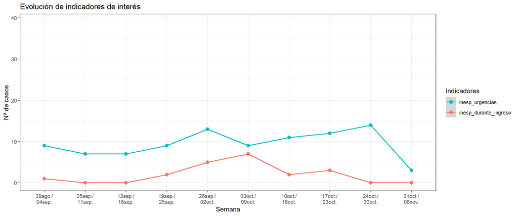

# 3 Evolución de casos covid

La media móvil se ha calculado con un periodo ventana de siete días. Cada punto en el eje de x coge esa fecha y todos los días entre el -3 y el +3.

|  | 29ago./ 04sep. | 05sep./ 11sep. | 12sep./ 18sep. | 19sep./ 25sep. | 26sep./ 02oct. | 03oct./ 09oct. | 10oct./ 16oct. | 17oct./ 23oct. | 24oct./ 30oct. | 31oct./ 06nov. |
| --- | --- | --- | --- | --- | --- | --- | --- | --- | --- | --- |
| Hospital U. de Cruces |  |  |  |  |  |  |  |  |  |  |
| Casos COVID totales | 19 | 8 | 12 | 15 | 25 | 29 | 21 | 26 | 30 | 11 |

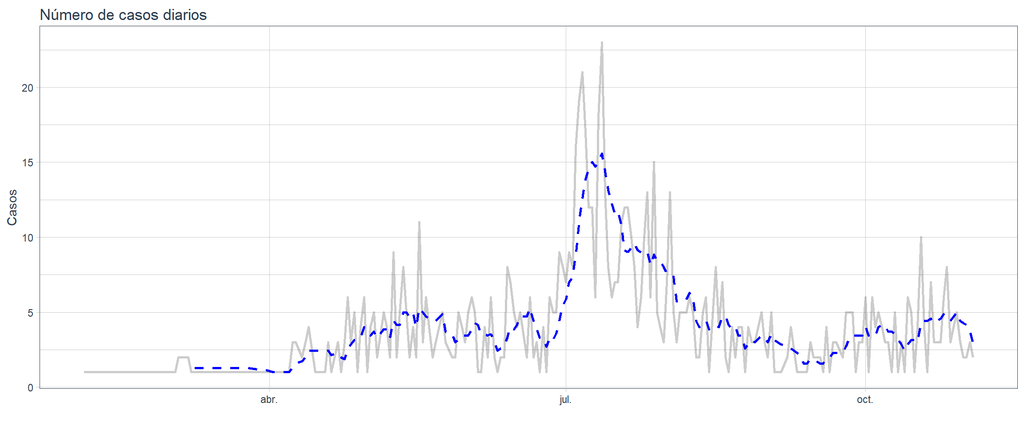

# 4 Nosocomiales por plantas

| planta | 29ago./ 04sep. | 19sep./ 25sep. | 26sep./ 02oct. | 03oct./ 09oct. | 10oct./ 16oct. | 17oct./ 23oct. |
| --- | --- | --- | --- | --- | --- | --- |
| 12C |  |  |  |  |  | 1579326 |
| 1D |  |  |  |  |  | 1564121 |
| 1E |  | 765954 | 327610 | 1776112, 86257, 1772831 | 527253 |  |
| 2B | 1995651 |  | 1162029 | 917466, 917895 |  |  |
| 2E |  |  |  | 1697697 |  |  |
| 3B |  |  | 1790826, 516750 |  |  |  |
| 3D |  |  |  | 10427853 | 2003853 | 10439623 |
| 5B |  | 11678739 |  |  |  |  |
| 7C |  |  | 299402 |  |  |  |

# 5 Positividad en la urgencia

| Characteristic | 29ago./ 04sep., N = 181 | 05sep./ 11sep., N = 81 | 12sep./ 18sep., N = 121 | 19sep./ 25sep., N = 131 | 26sep./ 02oct., N = 201 | 03oct./ 09oct., N = 221 | 10oct./ 16oct., N = 191 | 17oct./ 23oct., N = 231 | 24oct./ 30oct., N = 301 | 31oct./ 06nov., N = 111 |
| --- | --- | --- | --- | --- | --- | --- | --- | --- | --- | --- |
| Positividad en nuevos ingresos |  |  |  |  |  |  |  |  |  |  |
| Ingreso COVID normal | 39% | 38% | 25% | 38% | 35% | 55% | 37% | 39% | 57% | 73% |
| Positivo inesperado en urgencias | 61% | 62% | 75% | 62% | 65% | 45% | 63% | 61% | 43% | 27% |

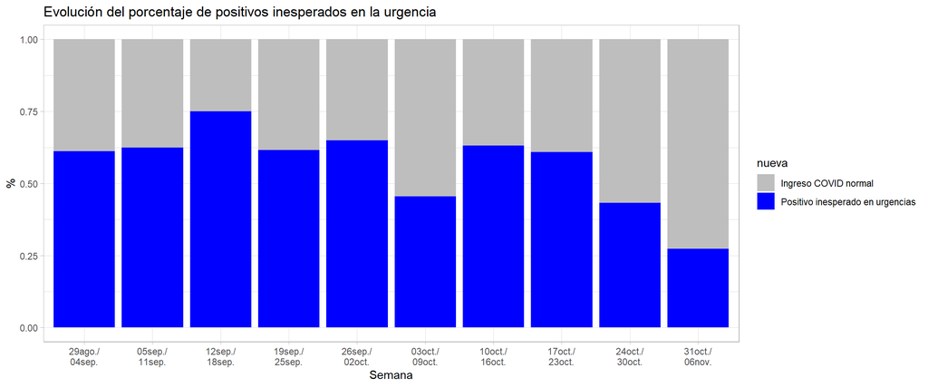

# 6 Monitorización del cambio de perfil de pacientes

[output not shown]

[output not shown]

Categorizando número de casos en diferentes fases clínicas.

| **Characteristic** | **a. 0-5 dias**, N = 71<sup>1</sup> | **b. 6-8 dias**, N = 3<sup>1</sup> | **c. 9-11 dias**, N = 2<sup>1</sup> | **d. >12 dias**, N = 1<sup>1</sup> |
| --- | --- | --- | --- | --- |
| dias | 0.00 (0.00, 1.00) | 7.00 (6.50, 7.00) | 9.50 (9.25, 9.75) | 22.00 (22.00, 22.00) |
| semana_ingreso |  |  |  |  |
| 25jul./ 31jul. | 0 (NA%) | 0 (NA%) | 0 (NA%) | 0 (NA%) |
| 15ago./ 21ago. | 0 (NA%) | 0 (NA%) | 0 (NA%) | 0 (NA%) |
| 22ago./ 28ago. | 0 (NA%) | 0 (NA%) | 0 (NA%) | 0 (NA%) |
| 29ago./ 04sep. | 7 (100%) | 0 (0%) | 0 (0%) | 0 (0%) |
| 05sep./ 11sep. | 3 (100%) | 0 (0%) | 0 (0%) | 0 (0%) |
| 12sep./ 18sep. | 3 (100%) | 0 (0%) | 0 (0%) | 0 (0%) |
| 19sep./ 25sep. | 5 (100%) | 0 (0%) | 0 (0%) | 0 (0%) |
| 26sep./ 02oct. | 6 (86%) | 1 (14%) | 0 (0%) | 0 (0%) |
| 03oct./ 09oct. | 11 (92%) | 1 (8.3%) | 0 (0%) | 0 (0%) |
| 10oct./ 16oct. | 7 (100%) | 0 (0%) | 0 (0%) | 0 (0%) |
| 17oct./ 23oct. | 8 (89%) | 0 (0%) | 1 (11%) | 0 (0%) |
| 24oct./ 30oct. | 14 (88%) | 1 (6.2%) | 1 (6.2%) | 0 (0%) |
| 31oct./ 06nov. | 7 (88%) | 0 (0%) | 0 (0%) | 1 (12%) |
| antes_julio |  |  |  |  |
| después del 10 de julio | 71 (92%) | 3 (3.9%) | 2 (2.6%) | 1 (1.3%) |

<sup>1</sup> Median (IQR); n (%)

Tabla para ver la concentración en los días 0 y 1.

| **Characteristic** | **0**, N = 44<sup>1</sup> | **1**, N = 20<sup>1</sup> | **2**, N = 3<sup>1</sup> | **3**, N = 1<sup>1</sup> | **4**, N = 2<sup>1</sup> | **más de 4**, N = 7<sup>1</sup> |
| --- | --- | --- | --- | --- | --- | --- |
| semana_ingreso |  |  |  |  |  |  |
| 25jul./ 31jul. | 0 (NA%) | 0 (NA%) | 0 (NA%) | 0 (NA%) | 0 (NA%) | 0 (NA%) |
| 15ago./ 21ago. | 0 (NA%) | 0 (NA%) | 0 (NA%) | 0 (NA%) | 0 (NA%) | 0 (NA%) |
| 22ago./ 28ago. | 0 (NA%) | 0 (NA%) | 0 (NA%) | 0 (NA%) | 0 (NA%) | 0 (NA%) |
| 29ago./ 04sep. | 4 (57%) | 2 (29%) | 0 (0%) | 0 (0%) | 1 (14%) | 0 (0%) |
| 05sep./ 11sep. | 1 (33%) | 2 (67%) | 0 (0%) | 0 (0%) | 0 (0%) | 0 (0%) |
| 12sep./ 18sep. | 2 (67%) | 1 (33%) | 0 (0%) | 0 (0%) | 0 (0%) | 0 (0%) |
| 19sep./ 25sep. | 5 (100%) | 0 (0%) | 0 (0%) | 0 (0%) | 0 (0%) | 0 (0%) |
| 26sep./ 02oct. | 3 (43%) | 3 (43%) | 0 (0%) | 0 (0%) | 0 (0%) | 1 (14%) |
| 03oct./ 09oct. | 5 (42%) | 4 (33%) | 1 (8.3%) | 0 (0%) | 0 (0%) | 2 (17%) |
| 10oct./ 16oct. | 2 (29%) | 5 (71%) | 0 (0%) | 0 (0%) | 0 (0%) | 0 (0%) |
| 17oct./ 23oct. | 6 (67%) | 2 (22%) | 0 (0%) | 0 (0%) | 0 (0%) | 1 (11%) |
| 24oct./ 30oct. | 10 (62%) | 0 (0%) | 2 (12%) | 1 (6.2%) | 1 (6.2%) | 2 (12%) |
| 31oct./ 06nov. | 6 (75%) | 1 (12%) | 0 (0%) | 0 (0%) | 0 (0%) | 1 (12%) |

<sup>1</sup> n (%)

| **Characteristic** | **25jul./ 31jul.**, N = 0<sup>1</sup> | **15ago./ 21ago.**, N = 0<sup>1</sup> | **22ago./ 28ago.**, N = 0<sup>1</sup> | **29ago./ 04sep.**, N = 7<sup>1</sup> | **05sep./ 11sep.**, N = 3<sup>1</sup> | **12sep./ 18sep.**, N = 3<sup>1</sup> | **19sep./ 25sep.**, N = 5<sup>1</sup> | **26sep./ 02oct.**, N = 7<sup>1</sup> | **03oct./ 09oct.**, N = 12<sup>1</sup> | **10oct./ 16oct.**, N = 7<sup>1</sup> | **17oct./ 23oct.**, N = 9<sup>1</sup> | **24oct./ 30oct.**, N = 17<sup>1</sup> | **31oct./ 06nov.**, N = 8<sup>1</sup> |
| --- | --- | --- | --- | --- | --- | --- | --- | --- | --- | --- | --- | --- | --- |
| dias | NA | NA | NA | 0.86 | 0.67 | 0.33 | 0.00 | 1.43 | 1.50 | 0.71 | 1.33 | 1.63 | 2.88 |
| Unknown | 0 | 0 | 0 | 0 | 0 | 0 | 0 | 0 | 0 | 0 | 0 | 1 | 0 |

<sup>1</sup> Mean

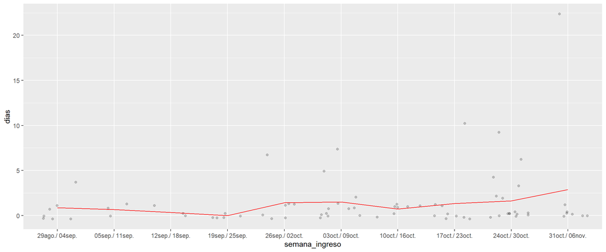

<sub>Servicio de Medicina Preventiva del Hospital Universitario de Cruces, **Jefa de Servicio**: Margarita Viciola</sub>